# **Trabalho de Extração de Conhecimento de Dados Biológicos**

#### **Grupo 1** - Ângela Sousa (*PG42489*), Luís Babo (*PG58817*) & Rúben Fernandes (*PG58818*)

Para a realização do trabalho da Unidade Curricular de Extração de Conhecimento de Dados Biológicos de 2025/2026, escolheu-se um conjunto de dados de expressão genética de leucemia mieloide aguda (AML) disponíveis na plataforma cBioPortal sob o nome "Acute Myeloid Leukemia (OHSU, Nature 2018)".

Os dados foram submetidos com o artigo "Functional genomic landscape of acute myeloid leukaemia" por Tyner et al., 2018, disponível através do doi: 10.1038/s41586-018-0623-z.

## **Origem dos Dados e a sua Relevância**

Este conjunto inclui dados de expressão génica e informação clínica associada aos pacientes.

A leucemia mieloide aguda é um tipo agressivo de cancro, sendo assim relevante estudar padrões de expressão genética para identificar genes diferencialmente expressos e possíveis biomarcadores.

A integração de dados clínicos com expressão génica permite análises mais completas e biologicamente relevantes.

## **Preparação e Pré-processamento dos Dados**

Iniciou-se a análise com a importação do dataset. Durante a importação em si, realizou-se a transposição da matriz de maneira a que as colunas correspondem-se às variáveis (genes) e as linhas às amostras (pacientes), garantindo assim a estrutura de dados adequada para futura análise estatística.

Posteriormente, foi necessário corrigir os nomes das colunas com a função colnames(), utilizando a primeira linha do dataset como cabeçalho das variáveis, sendo esta linha removida após essa operação.

De seguida, avaliou-se a presença de valores em falta (NA), confirmando-se a ausência dos mesmos no dataset.

Após este processo, obteve-se um conjunto de dados mais relevante e adequado para a análise de expressão diferencial. Por fim, confirmou-se a consistência dos dados e a correta organização das variáveis, garantindo a preparação do dataset para as análises subsequentes.

```r
library(BiocManager)
library(dplyr)
library(tibble)
library(limma)
library(ggplot2)
library(pheatmap)
library(randomForest)
library(ranger)
library(caret)
library(e1071)
library(MLCOPULA)
```

```r
data_zscores <- as.data.frame(
  t(read.delim("data_mrna_seq_cpm_zscores_ref_all_samples.txt"))
)
colnames(data_zscores) <- as.character(unlist(data_zscores[1,]))
data_zscores <- data_zscores[-1, ]
data_zscores <- data_zscores[-1, ]
```

```r
any(is.na(data_zscores))
```

```
## [1] FALSE
```

```r
df_filtered <- data_zscores[ , !(apply(data_zscores, 2, function(col) all(col >= -2 & col <= 2))) ]
```

```r
patient_info <- as.data.frame(read.delim("data_clinical_patient.txt", skip = 4, header = T))
any(is.na(patient_info))
```

```
## [1] TRUE
```

```r
patient_info<-na.omit(patient_info)
any(is.na(patient_info))
```

```
## [1] FALSE
```

Inicialmente, procedeu-se à importação do dataset. Foi necessário transpor a matriz de dados, de modo a organizar as amostras em linhas e as variáveis (genes) em colunas, garantindo assim uma estrutura adequada para análise estatística. Posteriormente, ajustaram-se os nomes das colunas, utilizando a primeira linha do dataset como cabeçalho das variáveis, sendo esta linha removida após essa operação. De seguida, avaliou-se a presença de valores em falta (NA), confirmando-se a ausência dos mesmos no dataset. Foi então realizada uma etapa de filtragem dos dados, com o objetivo de remover genes com baixa variabilidade entre amostras. Para tal, excluíram-se os genes cujos valores de expressão se encontravam dentro de um intervalo restrito (entre -2 e 2) em todas as amostras, por serem considerados pouco informativos para análises posteriores. Após este processo, obteve-se um conjunto de dados mais relevante e adequado para a análise de expressão diferencial. Por fim, confirmou-se a consistência dos dados e a correta organização das variáveis, garantindo a preparação do dataset para as análises subsequentes.

## **Sumarização dos Dados**

```r
sapply(patient_info[, sapply(patient_info, is.numeric)], summary)
```

```
##         AGE_AT_DIAGNOSIS OS_MONTHS   CENTER
## Min.             1.00000    0.0300 1.000000
## 1st Qu.         48.00000    5.1900 1.000000
## Median          61.00000   10.1950 1.000000
## Mean            57.27621   14.1903 2.235887
## 3rd Qu.         71.00000   17.5925 3.000000
## Max.            87.00000  174.5100 7.000000
```

```r
char_cols <- sapply(patient_info[, -1], is.character)

sapply(patient_info[, -1][, char_cols], table)
```

```
## $SEX
##
## Female   Male
##    223    273
##
## $ETHNICITY
##
## AdmixedAsian AdmixedBlack AdmixedWhite        Asian        Black   HispNative
##            1            2            1           14           18           42
##        White
##          418
##
## $MDSMPN_DIAGNOSIS_AT_ACQUISITION
##
## False  True
##   485    11
##
## $NON_AML_MDSMPN_DIAGNOSIS_AT_ACQUISITION
##
## False
##   496
##
## $PRIOR_CANCER
##
##                                                Adenocarcinoma
##                            433                              1
##   Anal carcinoma|Breast Cancer         Anaplastic Astrocytoma
##                              1                              1
##           Basal Cell Carcinoma                 Bladder Cancer
##                              1                              3
##  Bladder Cancer|Ovarian cancer                  Breast Cancer
##                              1                             12
##                Cervical Cancer                   Colon Cancer
##                              1                              2
##             Endometrial cancer              Esophageal Cancer
##                              1                              1
##            Follicular lymphoma Juvenile pilocytic astrocytoma
##                              2                              1
##                    Lung Cancer Lung Cancer|Multiple Sclerosis
##                              3                              1
```

[output cut: 148 more lines]

```
##                                                                                                                1
##                                                                                         Targeted Therapy - Other
##                                                                                                                3
##                                                                                                          Unknown
##                                                                                                                2
##
## $OS_STATUS
##
##   0:LIVING 1:DECEASED
##        207        289
##
## $CAUSE_OF_DEATH_SOURCE
##
##          Alive   Dead-Disease     Dead-Other Dead-Treatment   Dead-Unknown
##            207            191             21             15             62
```

## **Análise Estatística Univariada**

```r
df_num <- as.data.frame(lapply(df_filtered, function(x) as.numeric(as.character(x))))
rownames(df_num) <- rownames(df_filtered)

colunas_numericas <- c("AGE_AT_DIAGNOSIS", "OS_MONTHS")
colunas_validas <- intersect(colunas_numericas, colnames(patient_info))
summary(patient_info[, colunas_validas, drop = FALSE])
```

```
##  AGE_AT_DIAGNOSIS   OS_MONTHS
##  Min.   : 1.00    Min.   :  0.03
##  1st Qu.:48.00    1st Qu.:  5.19
##  Median :61.00    Median : 10.20
##  Mean   :57.28    Mean   : 14.19
##  3rd Qu.:71.00    3rd Qu.: 17.59
##  Max.   :87.00    Max.   :174.51
```

```r
table(patient_info$SEX)
```

```
##
## Female   Male
##    223    273
```

```r
table(patient_info$OS_STATUS)
```

```
##
##   0:LIVING 1:DECEASED
##        207        289
```

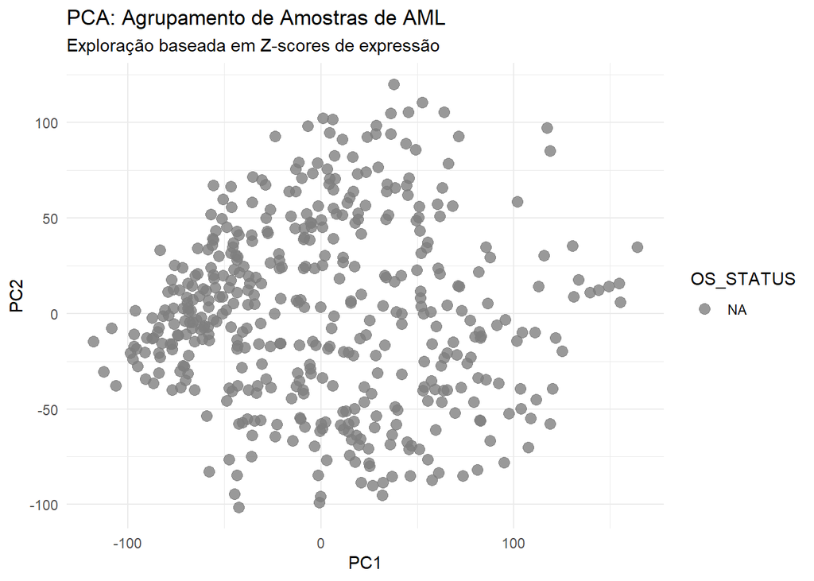

```r
pca_res <- prcomp(df_num, scale. = TRUE)
pca_data <- as.data.frame(pca_res$x)
pca_data$SAMPLE_ID <- rownames(pca_data)

sample_info <- as.data.frame(read.delim("data_clinical_sample.txt", skip = 4, header = TRUE))
clinica_completa <- left_join(sample_info, patient_info, by = "PATIENT_ID")
viz_data <- left_join(pca_data, clinica_completa, by = "SAMPLE_ID")

ggplot(viz_data, aes(x = PC1, y = PC2, color = OS_STATUS)) +
  geom_point(size = 3, alpha = 0.8) +
  theme_minimal() +
  labs(
    title = "PCA: Agrupamento de Amostras de AML",
    subtitle = "Exploração baseada em Z-scores de expressão"
  )
```

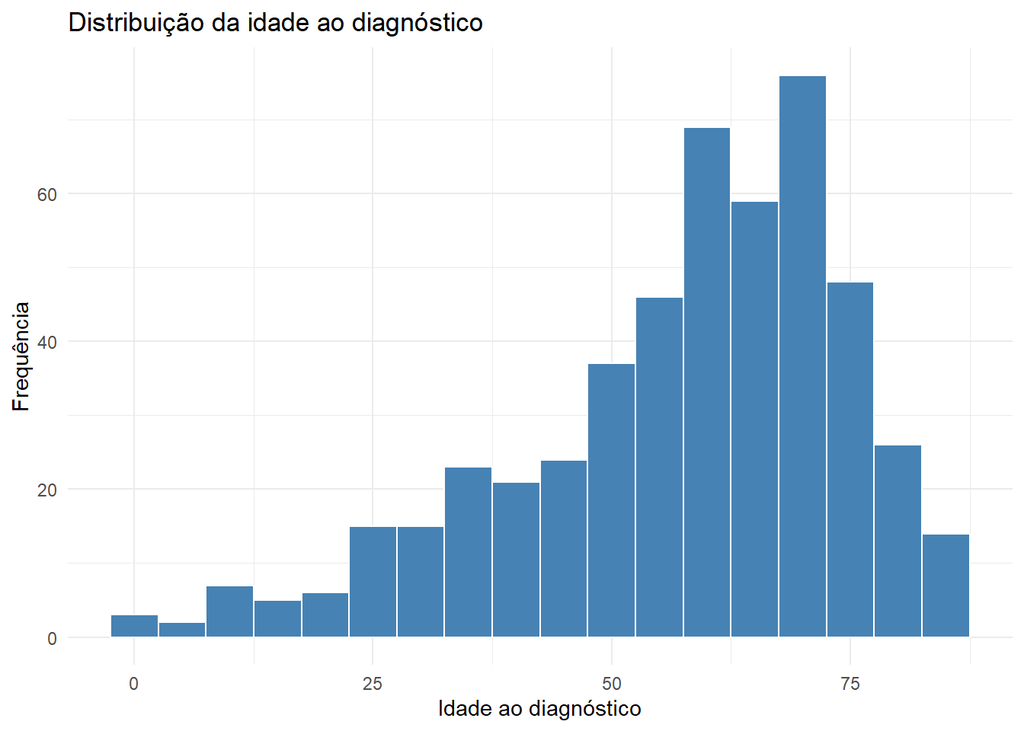

```r
ggplot(patient_info, aes(x = AGE_AT_DIAGNOSIS)) +
  geom_histogram(binwidth = 5, fill = "steelblue", color = "white") +
  theme_minimal() +
  labs(
    title = "Distribuição da idade ao diagnóstico",
    x = "Idade ao diagnóstico",
    y = "Frequência"
  )
```

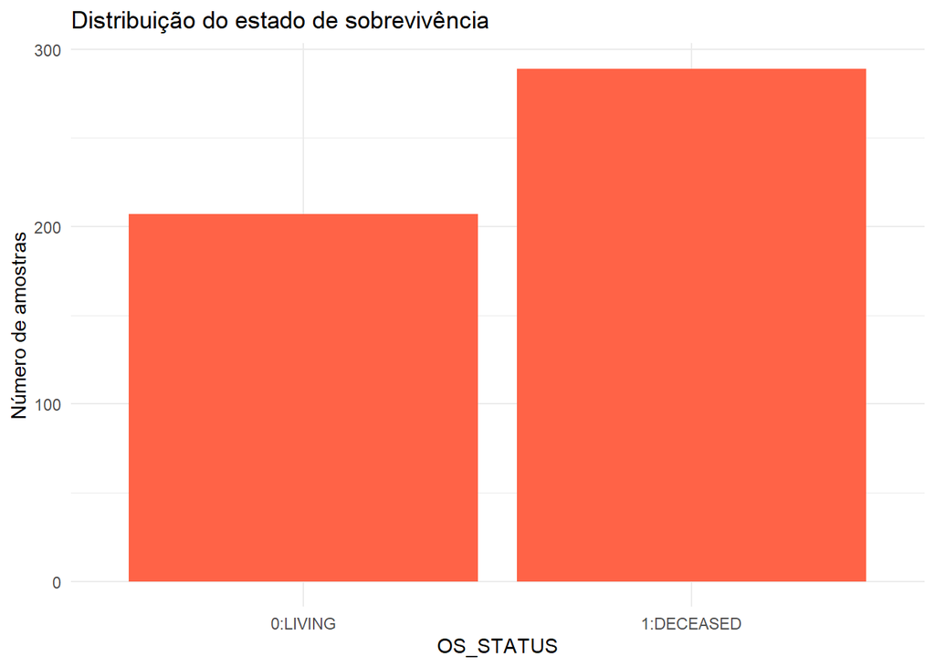

```r
ggplot(patient_info, aes(x = OS_STATUS)) +
  geom_bar(fill = "tomato") +
  theme_minimal() +
  labs(
    title = "Distribuição do estado de sobrevivência",
    x = "OS_STATUS",
    y = "Número de amostras"
  )
```

## **Análise de Expressão Diferencial e de Enriquecimento**

```r
expr_mat <- t(as.matrix(df_num))
mode(expr_mat) <- "numeric"

expr_ids <- colnames(expr_mat)

sample_info <- as.data.frame(read.delim("data_clinical_sample.txt", skip = 4, header = TRUE))

sample_info2 <- sample_info %>%
  mutate(
    SAMPLE_ID_RAW = SAMPLE_ID,
    SAMPLE_ID_A = SAMPLE_ID,
    SAMPLE_ID_B = paste0("aml_ohsu_2018_", SAMPLE_ID),
    SAMPLE_ID_C = gsub("-", ".", SAMPLE_ID),
    SAMPLE_ID_D = paste0("aml_ohsu_2018_", gsub("-", ".", SAMPLE_ID))
  )

matches <- c(
  A = sum(sample_info2$SAMPLE_ID_A %in% expr_ids),
  B = sum(sample_info2$SAMPLE_ID_B %in% expr_ids),
  C = sum(sample_info2$SAMPLE_ID_C %in% expr_ids),
  D = sum(sample_info2$SAMPLE_ID_D %in% expr_ids)
)

best_format <- names(which.max(matches))

sample_info2$SAMPLE_ID_MATCH <- switch(
  best_format,
  A = sample_info2$SAMPLE_ID_A,
  B = sample_info2$SAMPLE_ID_B,
  C = sample_info2$SAMPLE_ID_C,
  D = sample_info2$SAMPLE_ID_D
)

dados_deg <- left_join(sample_info2, patient_info, by = "PATIENT_ID")

dados_deg <- dados_deg %>%
  filter(SAMPLE_ID_MATCH %in% expr_ids) %>%
  filter(!is.na(OS_STATUS), OS_STATUS %in% c("0:LIVING", "1:DECEASED")) %>%
  arrange(match(SAMPLE_ID_MATCH, expr_ids))

expr_deg <- expr_mat[, dados_deg$SAMPLE_ID_MATCH, drop = FALSE]

all(dados_deg$SAMPLE_ID_MATCH == colnames(expr_deg))
```

```
## [1] TRUE
```

```r
grupo <- factor(dados_deg$OS_STATUS, levels = c("0:LIVING", "1:DECEASED"))

table(grupo)
```

```
## grupo
##   0:LIVING 1:DECEASED
##        167        237
```

```r
design <- model.matrix(~ grupo)
fit <- lmFit(expr_deg, design)
fit <- eBayes(fit)

res_deg <- topTable(fit, coef = 2, number = Inf)
res_deg$gene <- rownames(res_deg)

sig_deg <- res_deg %>% filter(adj.P.Val < 0.05)

head(sig_deg)
```

```
##              logFC      AveExpr         t      P.Value    adj.P.Val         B
## TJP2     0.5965777  0.040996535  6.112437 1.668688e-09 3.811783e-05 11.070160
## CD109    0.5490822  0.001581931  5.593809 3.242625e-08 3.359035e-04  8.363871
## FNDC3B  -0.5399650 -0.001795792 -5.537642 4.411463e-08 3.359035e-04  8.083755
## NRIP1    0.5265722  0.017379208  5.394973 9.527074e-08 5.440674e-04  7.383774
## EGLN3    0.5307201 -0.011819802  5.327215 1.365025e-07 5.532105e-04  7.057165
## LRRC16A  0.5259389  0.021457426  5.315362 1.453077e-07 5.532105e-04  7.000416
##            gene
## TJP2       TJP2
## CD109     CD109
## FNDC3B   FNDC3B
## NRIP1     NRIP1
## EGLN3     EGLN3
## LRRC16A LRRC16A
```

```r
nrow(sig_deg)
```

```
## [1] 642
```

# FASE 2: Análise Não Supervisionada

## **Clustering Hierárquico**

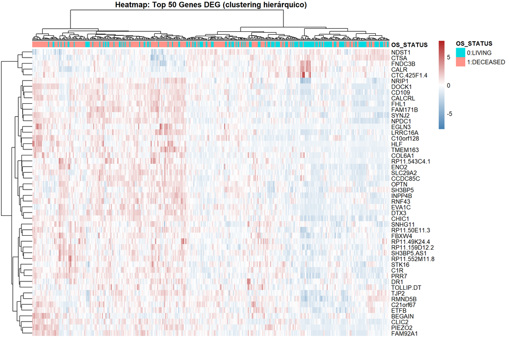

```r
top_genes <- sig_deg %>%
  arrange(adj.P.Val) %>%
  head(50) %>%
  pull(gene)

expr_top <- expr_deg[top_genes, , drop = FALSE]
mode(expr_top) <- "numeric"

anotacao_amostras <- data.frame(
  OS_STATUS = dados_deg$OS_STATUS,
  row.names = dados_deg$SAMPLE_ID_MATCH
)

pheatmap(
  expr_top,
  annotation_col   = anotacao_amostras,
  show_colnames    = FALSE,
  scale            = "row",
  clustering_method = "ward.D2",
  color            = colorRampPalette(c("steelblue", "white", "firebrick"))(100),
  main             = "Heatmap: Top 50 Genes DEG (clustering hierárquico)"
)
```

O *heatmap* com *clustering* hierárquico (método de **Ward.D2**) aplicado aos 50 genes com maior expressao diferencial revela uma estrutura de expressão com dois grandes grupos de genes, visível no dendrograma do eixo vertical. A barra de anotação superior indica a distribuição do estado de sobrevivência (0:LIVING a azul e 1:DECEASED a vermelho), não se observando uma separação clara entre os dois grupos clínicos ao longo do eixo horizontal. Isto sugere que, embora existam padrões de expressão distintos entre subconjuntos de genes, o estado de sobrevivência por si só não estabelece grupos moleculares claramente separáveis, o que é consistente com a elevada heterogeneidade molecular caraterística da AML. Genes como *TJP2*, *FNDC3B*, *NRIP1* e *CD109* destacam-se pelo seu padrão de expressão diferencial, apresentando valores mais elevados em determinados subgrupos de amostras.

## **K-means Clustering**

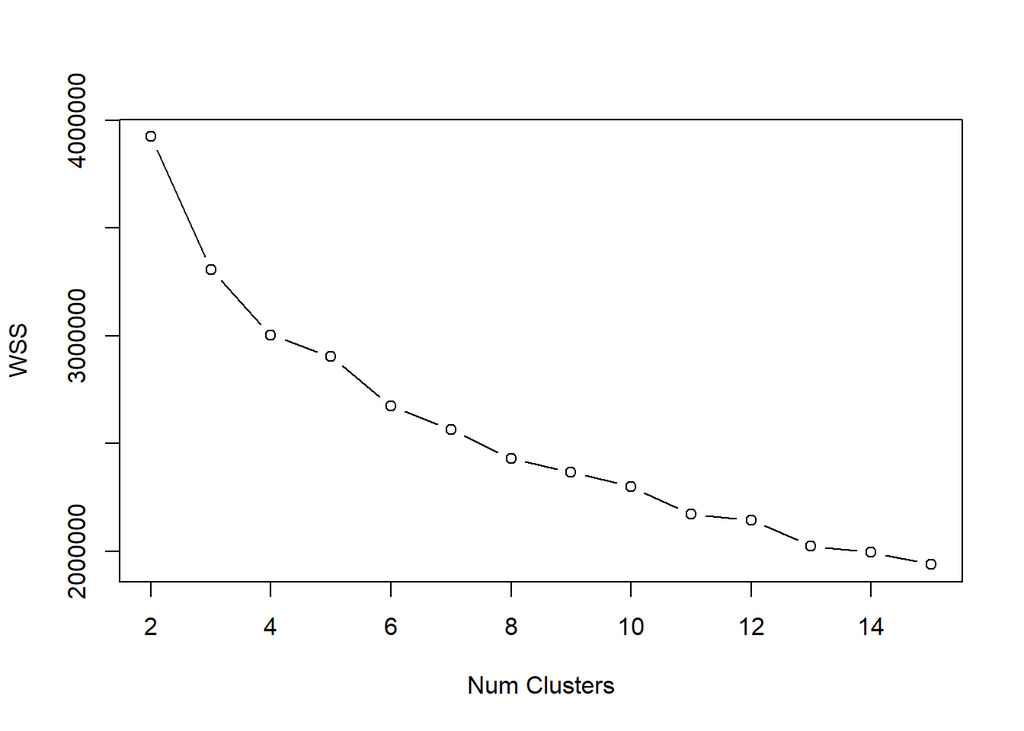

```r
pca_kmeans <- prcomp(df_num, scale = T)
dados_kmeans <- pca_kmeans$x[,1:10]

wss = c()
for (k in 2:15)
  wss = c(wss, sum(kmeans(dados_kmeans, centers = k)$withinss))

plot(2:15, wss, type = "b", xlab = "Num Clusters", ylab = "WSS")
```

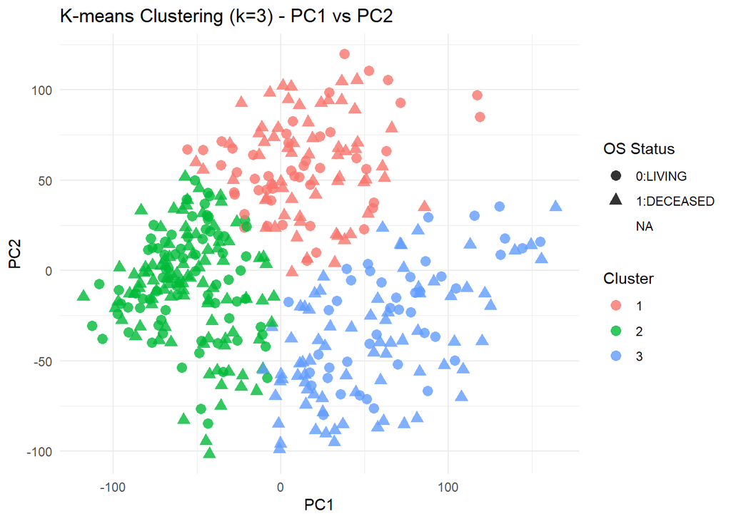

```r
set.seed(42)
pca_scores <- as.data.frame(pca_kmeans$x[, 1:10])
k_opt <- 3
km_res <- kmeans(pca_scores, centers = k_opt, nstart = 25, iter.max = 100)


pca_scores$cluster <- as.factor(km_res$cluster)
pca_scores$OS_STATUS <- dados_deg$OS_STATUS[match(rownames(pca_scores), dados_deg$SAMPLE_ID_MATCH)]

ggplot(pca_scores, aes(x = PC1, y = PC2, color = cluster, shape = OS_STATUS)) +
  geom_point(size = 3, alpha = 0.8) +
  theme_minimal() +
  labs(
    title = paste0("K-means Clustering (k=", k_opt, ") - PC1 vs PC2"),
    color = "Cluster",
    shape = "OS Status"
  )
```

```r
table(Cluster = km_res$cluster, OS_STATUS = pca_scores$OS_STATUS)
```

```
##        OS_STATUS
## Cluster 0:LIVING 1:DECEASED
##       1       48         63
##       2       76         98
##       3       43         76
```

## **Redução de Dimensionalidade**

### MDS (Multidimensional Scaling)

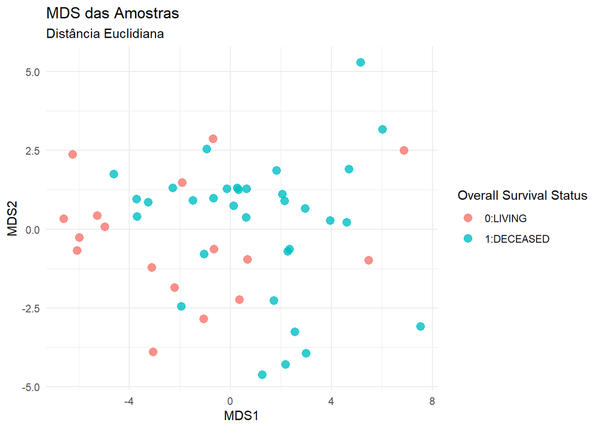

```r
set.seed(42)

n_amostras <- min(50, ncol(expr_top))
idx <- sample(1:ncol(expr_top), n_amostras)
expr_mds <- expr_top[, idx]

dist_mat <- dist(t(expr_mds), method = "euclidean")
mds_res  <- cmdscale(dist_mat, k = 2)

mds_df <- as.data.frame(mds_res)
colnames(mds_df) <- c("MDS1", "MDS2")
mds_df$SAMPLE_ID <- rownames(mds_df)

mds_df <- left_join(
  mds_df,
  dplyr::select(dados_deg, SAMPLE_ID_MATCH, `OS_STATUS`),
  by = c("SAMPLE_ID" = "SAMPLE_ID_MATCH")
)

ggplot(mds_df, aes(x = MDS1, y = MDS2, color = `OS_STATUS`)) +
  geom_point(size = 3, alpha = 0.8) +
  theme_minimal() +
  labs(
    title = "MDS das Amostras",
    subtitle = "Distância Euclidiana",
    color = "Overall Survival Status"
  )
```

O gráfico de Multidimensional Scaling (MDS) com distância euclidiana representa as amostras num espaço bidimensional de forma a preservar as distâncias originais entre elas no espaço de expressão genética. As amostras encontram-se distribuídas de forma relativamente homogénea ao longo dos dois eixos, sem formação de grupos claramente separados. A coloração por estado de sobrevivência (0:LIVING a rosa e 1:DECEASED a azul) não revela uma separação espacial consistente entre os dois grupos, estando ambas as classes misturadas ao longo de todo o espaço representado. Este resultado é concordante com as análises anteriores e reforça a ideia de que a variabilidade global da expressão genética em AML não é explicada unicamente pelo estado de sobrevivência, refletindo a complexidade e heterogeneidade molecular desta doença.

# FASE 3: Aprendizagem de Máquina

## **Preparação do Dataset**

```r
df_filtered$sample_id <- gsub("\\.", "-", rownames(df_filtered))

merge_table <- merge(df_filtered, clinica_completa,
                     by.x = "sample_id", by.y = "SAMPLE_ID")

merge_full <- merge(merge_table, patient_info, by = "PATIENT_ID")

merge_full <- merge_full %>%
  mutate(TREATMENT_TYPE = ifelse(TREATMENT_TYPE.x == "Standard Chemotherapy",
                                  "Standard Chemotherapy",
                                  "Other"))
merge_full <- merge_full %>%
  filter(!is.na(TREATMENT_TYPE))

merge_full$TREATMENT_TYPE <- as.factor(merge_full$TREATMENT_TYPE)

table(merge_full$TREATMENT_TYPE)
```

```
##
##                 Other Standard Chemotherapy
##                   225                   179
```

```r
top_genes_ml <- sig_deg %>%
  arrange(adj.P.Val) %>%
  head(100) %>%
  pull(gene)

top_genes_ml <- make.names(top_genes_ml)

colnames(merge_full) <- make.names(colnames(merge_full))

top_genes_ml <- intersect(top_genes_ml, colnames(merge_full))

df_ml <- merge_full %>%
  dplyr::select(PATIENT_ID, sample_id, all_of(top_genes_ml), TREATMENT_TYPE) %>%
  mutate(across(all_of(top_genes_ml), as.numeric))
```

A intenção com a aprendizagem de máquina é de obter um modelo capaz de prever o tipo de tratamento com base nos dados de expressão genética. Antes de proceder para a aprendizagem de máquina, foi necessário preparar os datasets apropriados, sendo estes o *df_filtered* (que contém os dados de expressão genética associados a SAMPLE_id), o *clinica_completa* (que contém os SAMPLE_ID e os PATIENT_ID) e o *patient_info* (que contém a informação completa sobre os pacientes, e que contém a coluna PATIENT_ID). Os datasets *df_filtered* e *clinica_completa* foram unidos pela coluna em comum, SAMPLE_ID. No entanto, o formato do conteúdo difere entre os dois, daí que se teve de proceder com um passo inicial de homogeneização. Após a junção destes datasets, seguiu-se com a junção com o *patient_info* pela coluna PATIENT_ID. Assim, ficou-se com um dataset (*merge_full*) com a informação completa para a aprendizagem de máquina.

A variável alvo escolhida para a classificação foi a TREATMENT_TYPE. Uma vez que esta coluna apresentava uma grande heterogeneidade de categorias, procedeu-se à sua simplificação em duas classes: **Standard Chemotherapy** para os pacientes que receberam exclusivamente quimioterapia base, e **Other** para todos os restantes tratamentos. As amostras sem informação de tratamento foram excluídas da análise.

Por fim, selecionaram-se os 100 genes diferencialmente expressos mais significativos (ordenados pelo adj.P.Val do sig_deg) como *features* para os modelos de aprendizagem, garantindo que apenas genes com relevância biológica foram utilizados na classificação.

```r
set.seed(12345)
ind = sample(2, nrow(df_ml), replace=TRUE, prob=c(0.7, 0.3))
trainData = df_ml[ind==1,]
testData = df_ml[ind==2,]
```

Para se realizar a aprendizagem de máquina, escolheu-se organizar os 100 genes diferencialmente expressos (*df_ml*) em dois datasets: um de treino com 70% dos dados e um de teste com 30%.

## **Random Forest**

```r
df_ml_rf <- randomForest(TREATMENT_TYPE ~ ., data = trainData, importance = TRUE)
pred_rf <- predict(df_ml_rf, testData)

confusionMatrix(pred_rf, testData$TREATMENT_TYPE)
```

```
## Confusion Matrix and Statistics
##
##                        Reference
## Prediction              Other Standard Chemotherapy
##   Other                    62                    29
##   Standard Chemotherapy    18                    33
##
##                Accuracy : 0.669
##                  95% CI : (0.5852, 0.7456)
##     No Information Rate : 0.5634
##     P-Value [Acc > NIR] : 0.006577
##
##                   Kappa : 0.3135
##
##  Mcnemar's Test P-Value : 0.144661
##
##             Sensitivity : 0.7750
##             Specificity : 0.5323
##          Pos Pred Value : 0.6813
##          Neg Pred Value : 0.6471
##              Prevalence : 0.5634
##          Detection Rate : 0.4366
##    Detection Prevalence : 0.6408
##       Balanced Accuracy : 0.6536
##
##        'Positive' Class : Other
##
```

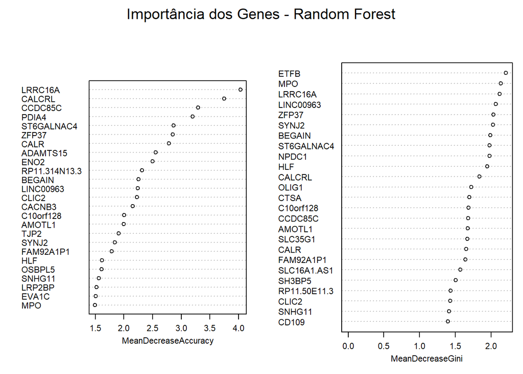

```r
par(mar = c(5, 10, 4, 2))

varImpPlot(df_ml_rf,
           main = "Importância dos Genes - Random Forest",
           n.var = 25,          # mostrar só top 20
           cex = 0.7)           # tamanho do texto
```

O primeiro modelo utilizado foi o **Random Forest**, treinado com os 100 genes DEG mais significativos, usando o mesmo split de treino (70%) e teste (30%). O modelo obteve uma **accuracy de 66.9%**, com uma sensibilidade de 0.775 e uma especificidade de 0.532, o que indica que o modelo é mais eficaz a identificar a classe *“Other”* do que a classe *“Standard Chemotherapy”*. O valor de Kappa de 0.31 indica uma concordância moderada entre as previsões e os valores reais.

## **SVM**

```r
df_ml_svm <- df_ml %>%
  dplyr::select(-PATIENT_ID, -sample_id)

trainData_svm <- df_ml_svm[ind == 1, ]
testData_svm  <- df_ml_svm[ind == 2, ]

# SVM com kernel linear
svm_model <- svm(TREATMENT_TYPE ~ ., data = trainData_svm, kernel = "linear")
pred_svm <- predict(svm_model, testData_svm)

# Resultados
confusionMatrix(pred_svm, testData_svm$TREATMENT_TYPE)
```

```
## Confusion Matrix and Statistics
##
##                        Reference
## Prediction              Other Standard Chemotherapy
##   Other                    43                    26
##   Standard Chemotherapy    37                    36
##
##                Accuracy : 0.5563
##                  95% CI : (0.4707, 0.6396)
##     No Information Rate : 0.5634
##     P-Value [Acc > NIR] : 0.6014
##
##                   Kappa : 0.1158
##
##  Mcnemar's Test P-Value : 0.2077
##
##             Sensitivity : 0.5375
##             Specificity : 0.5806
##          Pos Pred Value : 0.6232
##          Neg Pred Value : 0.4932
##              Prevalence : 0.5634
##          Detection Rate : 0.3028
##    Detection Prevalence : 0.4859
##       Balanced Accuracy : 0.5591
##
##        'Positive' Class : Other
##
```

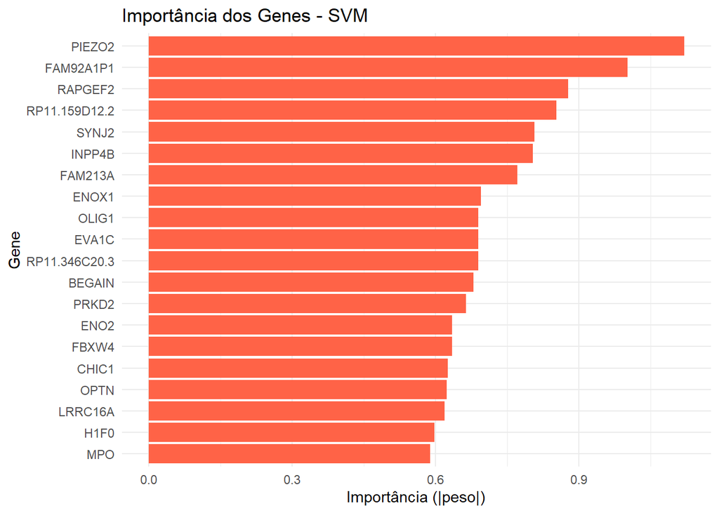

```r
# Importância dos genes
svm_weights <- t(svm_model$coefs) %*% svm_model$SV
svm_imp_df <- data.frame(
  gene = colnames(svm_weights),
  importance = abs(svm_weights[1, ])
)

# Gráfico top 25
svm_imp_df %>%
  arrange(desc(importance)) %>%
  head(20) %>%
  ggplot(aes(x = reorder(gene, importance), y = importance)) +
  geom_bar(stat = "identity", fill = "tomato") +
  coord_flip() +
  theme_minimal() +
  labs(title = "Importância dos Genes - SVM",
       x = "Gene",
       y = "Importância (|peso|)")
```

O segundo modelo utilizado foi o **Support Vector Machine (SVM)** com kernel linear, treinado com o mesmo conjunto de 100 genes DEG e o mesmo split de treino/teste. O kernel linear foi escolhido por permitir a extração dos pesos associados a cada gene, possibilitando assim a interpretação da importância das variáveis.

O modelo SVM obteve uma **accuracy de 55.63%**, com uma sensibilidade de 0.538 e uma especificidade de 0.581, e um Kappa de 0.116, indicando uma concordância fraca entre as previsões e os valores reais. O *classification report* revelou uma precision de 0.623 e um F1-score de 0.577 para a classe *“Other”*, e uma precision de 0.493 e F1-score de 0.533 para *“Standard Chemotherapy”*, evidenciando dificuldade do modelo em distinguir as duas classes. A análise de importância identificou os genes **PIEZO2, FAM92A1P1, RAPGEF2** e **RP11.159D12.2** como os mais relevantes, uma lista parcialmente distinta da obtida pelo Random Forest, o que sugere que os dois modelos capturam diferentes aspetos da variabilidade de expressão génica associada ao tipo de tratamento.

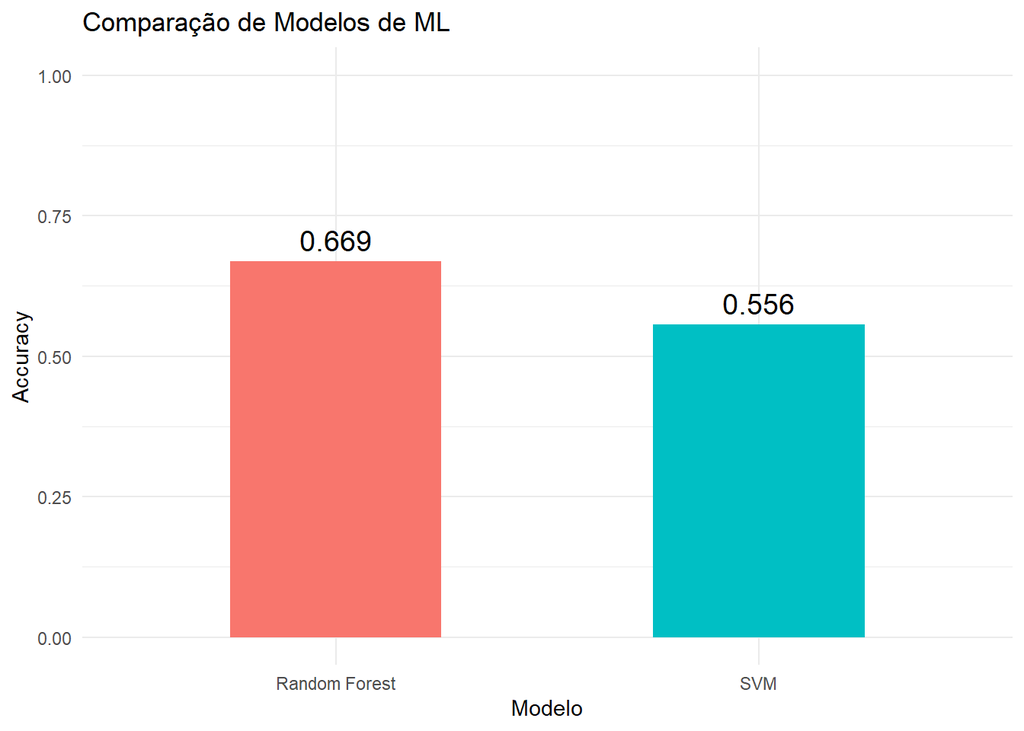

```r
# Comparação de accuracy entre modelos
resultados <- data.frame(
  Modelo = c("Random Forest", "SVM"),
  Accuracy = c(mean(pred_rf == testData$TREATMENT_TYPE),
               mean(pred_svm == testData_svm$TREATMENT_TYPE))
)

ggplot(resultados, aes(x = Modelo, y = Accuracy, fill = Modelo)) +
  geom_bar(stat = "identity", width = 0.5) +
  geom_text(aes(label = round(Accuracy, 3)), vjust = -0.5, size = 5) +
  ylim(0, 1) +
  theme_minimal() +
  labs(title = "Comparação de Modelos de ML",
       x = "Modelo",
       y = "Accuracy") +
  theme(legend.position = "none")
```

```r
classification_report(y_true = testData$TREATMENT_TYPE, y_pred = pred_rf)
```

```
## $metrics
##                       precision    recall  f1-score
## Other                 0.6813187 0.7750000 0.7251462
## Standard Chemotherapy 0.6470588 0.5322581 0.5840708
##
## $confusion_matrix
##                        y_pred
## y_true                  Other Standard Chemotherapy
##   Other                    62                    18
##   Standard Chemotherapy    29                    33
##
## $accuracy
## [1] 0.6690141
##
## $mutual_information
## [1] 0.05082401
```

```r
classification_report(y_true = testData_svm$TREATMENT_TYPE, y_pred = pred_svm)
```

```
## $metrics
##                       precision    recall  f1-score
## Other                 0.6231884 0.5375000 0.5771812
## Standard Chemotherapy 0.4931507 0.5806452 0.5333333
##
## $confusion_matrix
##                        y_pred
## y_true                  Other Standard Chemotherapy
##   Other                    43                    37
##   Standard Chemotherapy    26                    36
##
## $accuracy
## [1] 0.556338
##
## $mutual_information
## [1] 0.006893317
```

O Random Forest revelou-se assim o modelo mais adequado para este problema. A performance moderada de ambos os modelos poderá ser explicada pela heterogeneidade molecular da AML e pelo facto de o tipo de tratamento ser influenciado por fatores clínicos que não estão completamente refletidos nos dados de expressão génica.

# **Conclusão**

O presente trabalho teve como objetivo a análise de dados de expressão genética da leucemia mieloide aguda (AML), recorrendo a um conjunto de ferramentas bioinformáticas em R, desde a preparação dos dados até à aprendizagem automática.

Na **Fase 2**, recorreu-se a técnicas de clustering e redução de dimensionalidade para explorar a estrutura dos dados de forma não supervisionada. O clustering hierárquico e o K-means permitiram identificar grupos de amostras com perfis de expressão semelhantes, embora sem uma separação clara entre os grupos clínicos. A análise MDS confirmou a elevada heterogeneidade molecular das amostras, corroborando os resultados obtidos na Fase 1.

De forma geral, a performance moderada dos modelos poderá ser explicada pela elevada heterogeneidade molecular da AML e pelo facto do tipo de tratamento ser determinado por uma combinação de fatores clínicos e moleculares que não são completamente captadas pelos dados da expressão genética. Ainda assim, os resultados obtidos demonstram que a expressão genética contém informação relevante para a previsão do tipo de tratamento, sendo o Random Forest o modelo mais adequado para este problema.